# Project: Investigate No Show appointments Dataset

```
Text(0.5,1,'Gender Distribution in show dataset')
```

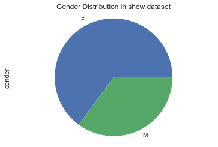

```python
df_show.gender.value_counts().plot(kind='pie')
plt.axis('equal')
plt.title('Gender Distribution in show dataset')
```

```python
# To find the distribution of health conditions among male and female patients who donot show up for the
# appointments we create 2 dataframes from the no show dateframe previously created for each male and female patients
df_noshow_male = df_show.query("gender =='M'")
df_noshow_female = df_show.query("gender =='F'")
```

```python
df_noshow_male.describe()
```

|  | patientid | appointmentid | age | scholarship | hipertension | diabetes | alcoholism | handicap | sms | noshow |
| --- | --- | --- | --- | --- | --- | --- | --- | --- | --- | --- |
| count | 3.096200e+04 | 3.096200e+04 | 30962.000000 | 30962.000000 | 30962.000000 | 30962.000000 | 30962.000000 | 30962.000000 | 30962.000000 | 30962.0 |
| mean | 1.503964e+14 | 5.682868e+06 | 34.461372 | 0.049609 | 0.172696 | 0.062141 | 0.057102 | 0.025418 | 0.265358 | 1.0 |
| std | 2.586355e+14 | 6.759881e+04 | 24.734056 | 0.217140 | 0.377990 | 0.241415 | 0.232042 | 0.157394 | 0.441531 | 0.0 |
| min | 4.374100e+04 | 5.134227e+06 | 0.000000 | 0.000000 | 0.000000 | 0.000000 | 0.000000 | 0.000000 | 0.000000 | 1.0 |
| 25% | 4.361221e+12 | 5.648013e+06 | 10.000000 | 0.000000 | 0.000000 | 0.000000 | 0.000000 | 0.000000 | 0.000000 | 1.0 |
| 50% | 3.348363e+13 | 5.686898e+06 | 34.000000 | 0.000000 | 0.000000 | 0.000000 | 0.000000 | 0.000000 | 0.000000 | 1.0 |
| 75% | 9.481864e+13 | 5.731822e+06 | 55.000000 | 0.000000 | 0.000000 | 0.000000 | 0.000000 | 0.000000 | 1.000000 | 1.0 |
| max | 9.999465e+14 | 5.790466e+06 | 100.000000 | 1.000000 | 1.000000 | 1.000000 | 1.000000 | 1.000000 | 1.000000 | 1.0 |

```python
df_noshow_female.describe()
```

|  | patientid | appointmentid | age | scholarship | hipertension | diabetes | alcoholism | handicap | sms | noshow |
| --- | --- | --- | --- | --- | --- | --- | --- | --- | --- | --- |
| count | 5.724500e+04 | 5.724500e+04 | 57245.000000 | 57245.000000 | 57245.000000 | 57245.000000 | 57245.000000 | 57245.000000 | 57245.000000 | 57245.0 |
| mean | 1.462122e+14 | 5.680199e+06 | 39.591126 | 0.117862 | 0.221539 | 0.080164 | 0.015984 | 0.018290 | 0.305389 | 1.0 |
| std | 2.551326e+14 | 7.020386e+04 | 22.342413 | 0.322447 | 0.415286 | 0.271550 | 0.125414 | 0.133999 | 0.460576 | 0.0 |
| min | 3.921700e+04 | 5.030230e+06 | 0.000000 | 0.000000 | 0.000000 | 0.000000 | 0.000000 | 0.000000 | 0.000000 | 1.0 |
| 25% | 3.957599e+12 | 5.645239e+06 | 22.000000 | 0.000000 | 0.000000 | 0.000000 | 0.000000 | 0.000000 | 0.000000 | 1.0 |
| 50% | 2.984123e+13 | 5.684941e+06 | 40.000000 | 0.000000 | 0.000000 | 0.000000 | 0.000000 | 0.000000 | 0.000000 | 1.0 |
| 75% | 9.389345e+13 | 5.730661e+06 | 57.000000 | 0.000000 | 0.000000 | 0.000000 | 0.000000 | 0.000000 | 1.000000 | 1.0 |
| max | 9.999816e+14 | 5.790484e+06 | 115.000000 | 1.000000 | 1.000000 | 1.000000 | 1.000000 | 1.000000 | 1.000000 | 1.0 |

```python
# Since we need to loop through the same task for each health condition we create a fucntion to calculate the
# number of Hipertension','Diabetes','Alcoholism','Handicap'
# in patients who donot show up for appointments

def distribution_healthconditions(condition,df,gender):
    '''Function take in 3 parameters health condition, gender, and the dataframe'''
    no_condition, yes_condition =df[condition].value_counts()
    print('Number of {} patients with no condition of {} : {}'.format(gender,condition,no))
    print('Number of {} patients with condition of {} : {}'.format(gender,condition,yes))
    return no_condition, yes_condition
```

```python
#create list of health conditions to be analyzed
health_conditions=['hipertension','diabetes','alcoholism','handicap']

# loop through each health conditon for male and female patients
for items in health_conditions:
    no, yes = distribution_healthconditions(items,df_noshow_male,"Male")
    no, yes = distribution_healthconditions(items,df_noshow_female,"Female")
```

[output not shown]

```
array([[<matplotlib.axes._subplots.AxesSubplot object at 0x1a45f9ef60>,
      dtype=object)
```

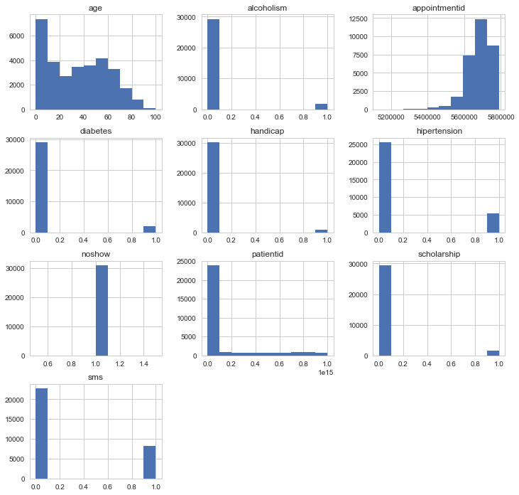

```python
df_noshow_male.hist(figsize=[12,12])
```

From the histogram graphs above we can infer hipertension is the most prevelant health condition among the male patients.

```
array([[<matplotlib.axes._subplots.AxesSubplot object at 0x1a4a557860>,
      dtype=object)
```

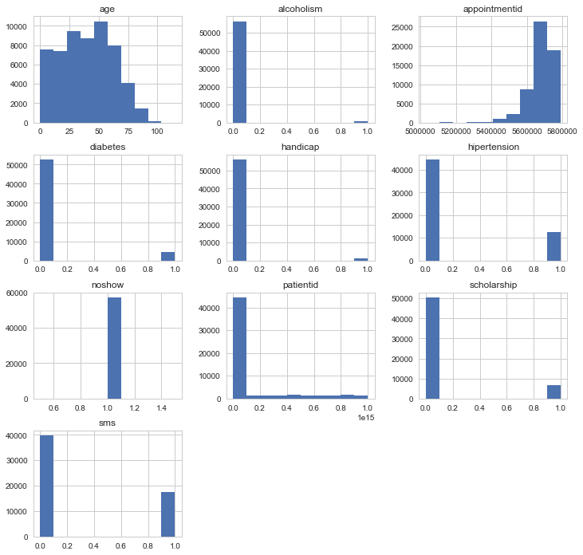

```python
df_noshow_female.hist(figsize=[12,12])
```

## Conclusions

#### Research Question 1 = Which neighbourhood has the most show of patients. What percentage of patients who show up for appointments receive scholarship and what is the gender distribution among those who receive scholarship?

#### Findings :

- The neighbourhood with the most number of patients who show up for the appointments is "JARDIM CAMBURI"
- Only a very small percentage ~9% of people who show up for appointments receive scholarship.
- Among patients who receive scholarship 6747 are Female and 1536 are male patients

#### Limitations :

- The analysis answers the question as to which neighbourhood has most patient show up. Further analysing data based on gender and age can give more insights.
- The number of patients who receive scholarship is very less and hence the scholarship feature has very less influence on the overall show and no-show of patients.

#### Limitations :

- Approximately ~20% of patients donot show up for the appointments from the overall dataset.
- The presence of health conditions and gender alone cannot be used as a determing factor for no show in appointments. Further investigating the factors such as age , sms_reveived will be useful to get better insights
- Also schedule day and appointment day attributes is not considered in the analysis above. These 2 features may have very significant influence on the no show of patients during appointments